# Assignment 5: Handle Missing Values

*How to do it?*:

- Open the Rmarkdown file of this assignment (link) in Rstudio.
- Right under each **question**, insert a code chunk (you can use the hotkey `Ctrl + Alt + I` to add a code chunk) and code the solution for the question.
- `Knit` the rmarkdown file (hotkey: `Ctrl + Alt + K`) to export an html.
- Publish the html file to your Githiub Page.

*Submission*: Submit the link on Github of the assignment to Canvas.

**The data:**

This assignment works with the Adult Census Data that can be downloaded at [this link.](https://bryantstats.github.io/math421/data/adult_census_missing.csv)

**Questions**

1. Use `read_csv` to import the data. Show the number of NAs for each columns.

```r
# Importing data
library(tidyverse)
df <- read_csv("adult_census.csv")

# Showing the number of NAs for each of the columns
colSums(is.na(df))
```

```
##            age      workclass         fnlwgt      education  education.num
##              0              0              0              0              0
## marital.status     occupation   relationship           race            sex
##              0              0              0              0              0
##   capital.gain   capital.loss hours.per.week native.country         income
##              0              0              0              0              0
```

2. Using function `aggr` the VIM package to plot the number of NAs for each column.

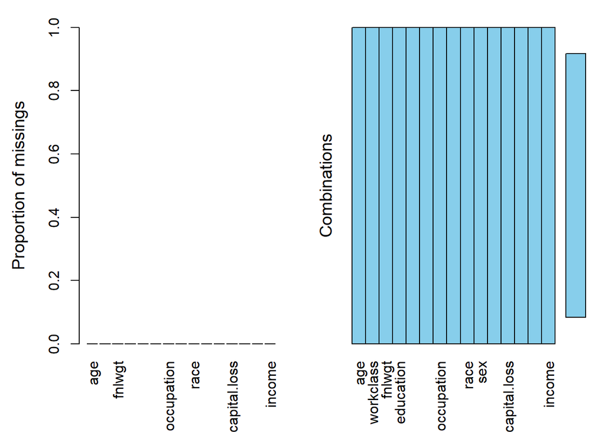

```r
# install.packages('VIM')
library(VIM)
aggr(df)
```

3. Find other forms of missing values. Hint: You can use the `table` function to check if there are suspicious categories (Unknown, for example) in a variable. What all other forms of missing values shown in the data.

```r
# Checking other missing value forms for age variable
table(df$age)
```

```
##
##  17  18  19  20  21  22  23  24  25  26  27  28  29  30  31  32  33  34  35  36
## 395 550 712 753 720 765 877 798 841 785 835 867 813 861 888 828 875 886 876 898
##  37  38  39  40  41  42  43  44  45  46  47  48  49  50  51  52  53  54  55  56
## 858 827 816 794 808 780 770 724 734 737 708 543 577 602 595 478 464 415 419 366
##  57  58  59  60  61  62  63  64  65  66  67  68  69  70  71  72  73  74  75  76
## 358 366 355 312 300 258 230 208 178 150 151 120 108  89  72  67  64  51  45  46
##  77  78  79  80  81  82  83  84  85  86  87  88  90
##  29  23  22  22  20  12   6  10   3   1   1   3  43
```

```r
# Checking other missing value forms for workclass variable
table(df$workclass)
```

```
##
##                ?      Federal-gov        Local-gov     Never-worked
##             1836              960             2093                7
##          Private     Self-emp-inc Self-emp-not-inc        State-gov
##            22696             1116             2541             1298
##      Without-pay
##               14
```

```r
# Can see that '?' represents missing values
```

```r
# Checking other missing value forms for education variable
table(df$education)
```

```
##
##         10th         11th         12th      1st-4th      5th-6th      7th-8th
##          933         1175          433          168          333          646
##          9th   Assoc-acdm    Assoc-voc    Bachelors    Doctorate      HS-grad
##          514         1067         1382         5355          413        10501
##      Masters    Preschool  Prof-school Some-college
##         1723           51          576         7291
```

```r
# Checking other missing value forms for education.num variable
table(df$education.num)
```

```
##
##     1     2     3     4     5     6     7     8     9    10    11    12    13
##    51   168   333   646   514   933  1175   433 10501  7291  1382  1067  5355
##    14    15    16
##  1723   576   413
```

```r
# Checking other missing value forms for marital.status variable
table(df$marital.status)
```

```
##
##              Divorced     Married-AF-spouse    Married-civ-spouse
##                  4443                    23                 14976
## Married-spouse-absent         Never-married             Separated
##                   418                 10683                  1025
##               Widowed
##                   993
```

```r
# Checking other missing value forms for occupation variable
table(df$occupation)
```

```
##
##                 ?      Adm-clerical      Armed-Forces      Craft-repair
##              1843              3770                 9              4099
##   Exec-managerial   Farming-fishing Handlers-cleaners Machine-op-inspct
##              4066               994              1370              2002
##     Other-service   Priv-house-serv    Prof-specialty   Protective-serv
##              3295               149              4140               649
##             Sales      Tech-support  Transport-moving
##              3650               928              1597
```

```r
# Can see that '?' represents missing values
```

```r
# Checking other missing value forms for relationship variable
table(df$relationship)
```

```
##
##        Husband  Not-in-family Other-relative      Own-child      Unmarried
##          13193           8305            981           5068           3446
##           Wife
##           1568
```

```r
# Checking other missing value forms for race variable
table(df$race)
```

```
##
## Amer-Indian-Eskimo Asian-Pac-Islander              Black              Other
##                311               1039               3124                271
##              White
##              27816
```

```r
# Checking other missing value forms for sex variable
table(df$sex)
```

```
##
## Female   Male
##  10771  21790
```

```r
# Checking other missing value forms for capital.gain variable
table(df$capital.gain)
```

```
##
##     0   114   401   594   914   991  1055  1086  1111  1151  1173  1409  1424
## 29849     6     2    34     8     5    25     4     1     8     3     7     3
##  1455  1471  1506  1639  1797  1831  1848  2009  2036  2050  2062  2105  2174
##     1     7    15     1     7     7     6     3     4     5     2     9    48
##  2176  2202  2228  2290  2329  2346  2354  2387  2407  2414  2463  2538  2580
##    23    16     5     5     6     6    11     1    19     8    11     1    12
##  2597  2635  2653  2829  2885  2907  2936  2961  2964  2977  2993  3103  3137
##    20    11     5    31    24    11     3     3     9     8     2    97    37
##  3273  3325  3411  3418  3432  3456  3464  3471  3674  3781  3818  3887  3908
##     6    53    24     5     4     2    23     8    14    12     7     6    32
##  3942  4064  4101  4386  4416  4508  4650  4687  4787  4865  4931  4934  5013
##    14    42    20    70    12    12    41     3    23    17     1     7    69
##  5060  5178  5455  5556  5721  6097  6360  6418  6497  6514  6723  6767  6849
##     1    97    11     5     3     1     3     9    11     5     2     5    27
##  7298  7430  7443  7688  7896  7978  8614  9386  9562 10520 10566 10605 11678
##   246     9     5   284     3     1    55    22     4    43     6    12     2
## 13550 14084 14344 15020 15024 15831 18481 20051 22040 25124 25236 27828 34095
##    27    41    26     5   347     6     2    37     1     4    11    34     5
## 41310 99999
##     2   159
```

```r
# Checking other missing value forms for capital.loss variable
table(df$capital.loss)
```

```
##
##     0   155   213   323   419   625   653   810   880   974  1092  1138  1258
## 31042     1     4     3     3    12     3     2     6     2     7     2     4
##  1340  1380  1408  1411  1485  1504  1539  1564  1573  1579  1590  1594  1602
##     7     7    21     1    51    18     1    25     6    20    40     8    47
##  1617  1628  1648  1651  1668  1669  1672  1719  1721  1726  1735  1740  1741
##     9    15     2     9     4    24    34    22    18     4     2    42    24
##  1755  1762  1816  1825  1844  1848  1876  1887  1902  1944  1974  1977  1980
##     2    14     2     4     1    51    39   159   202     1    18   168    23
##  2001  2002  2042  2051  2057  2080  2129  2149  2163  2174  2179  2201  2205
##    24    21     9    21     6     1     3     2     1     7    15     1     9
##  2206  2231  2238  2246  2258  2267  2282  2339  2352  2377  2392  2415  2444
##     6     3     2     6    25     3     1    17     2    20     9    49    12
##  2457  2467  2472  2489  2547  2559  2603  2754  2824  3004  3683  3770  3900
##     3     1     1     1     4    12     5     2    10     2     2     2     2
##  4356
##     3
```

```r
# Checking other missing value forms for hours.per.week variable
table(df$hours.per.week)
```

```
##
##     1     2     3     4     5     6     7     8     9    10    11    12    13
##    20    32    39    54    60    64    26   145    18   278    11   173    23
##    14    15    16    17    18    19    20    21    22    23    24    25    26
##    34   404   205    29    75    14  1224    24    44    21   252   674    30
##    27    28    29    30    31    32    33    34    35    36    37    38    39
##    30    86     7  1149     5   266    39    28  1297   220   149   476    38
##    40    41    42    43    44    45    46    47    48    49    50    51    52
## 15217    36   219   151   212  1824    82    49   517    29  2819    13   138
##    53    54    55    56    57    58    59    60    61    62    63    64    65
##    25    41   694    97    17    28     5  1475     2    18    10    14   244
##    66    67    68    70    72    73    74    75    76    77    78    80    81
##    17     4    12   291    71     2     1    66     3     6     8   133     3
##    82    84    85    86    87    88    89    90    91    92    94    95    96
##     1    45    13     2     1     2     2    29     3     1     1     2     5
##    97    98    99
##     2    11    85
```

```r
# Checking other missing value forms for native.country variable
table(df$native.country)
```

```
##
##                          ?                   Cambodia
##                        583                         19
##                     Canada                      China
##                        121                         75
##                   Columbia                       Cuba
##                         59                         95
##         Dominican-Republic                    Ecuador
##                         70                         28
##                El-Salvador                    England
##                        106                         90
##                     France                    Germany
##                         29                        137
##                     Greece                  Guatemala
##                         29                         64
##                      Haiti         Holand-Netherlands
##                         44                          1
##                   Honduras                       Hong
##                         13                         20
##                    Hungary                      India
##                         13                        100
##                       Iran                    Ireland
##                         43                         24
##                      Italy                    Jamaica
##                         73                         81
##                      Japan                       Laos
##                         62                         18
##                     Mexico                  Nicaragua
##                        643                         34
## Outlying-US(Guam-USVI-etc)                       Peru
##                         14                         31
##                Philippines                     Poland
##                        198                         60
##                   Portugal                Puerto-Rico
##                         37                        114
##                   Scotland                      South
##                         12                         80
##                     Taiwan                   Thailand
##                         51                         18
##            Trinadad&Tobago              United-States
##                         19                      29170
##                    Vietnam                 Yugoslavia
##                         67                         16
```

```r
# Can see that '?' represents missing values
```

```r
# Checking other missing value forms for income variable
table(df$income)
```

```
##
## <=50K  >50K
## 24720  7841
```

4. Replace all the forms of missing values found to NA

```r
# Only need to account for '?' for other missing value form
df <- replace(df, df == '?', NA)
```

5. Re-plot the number of NAs for each column.

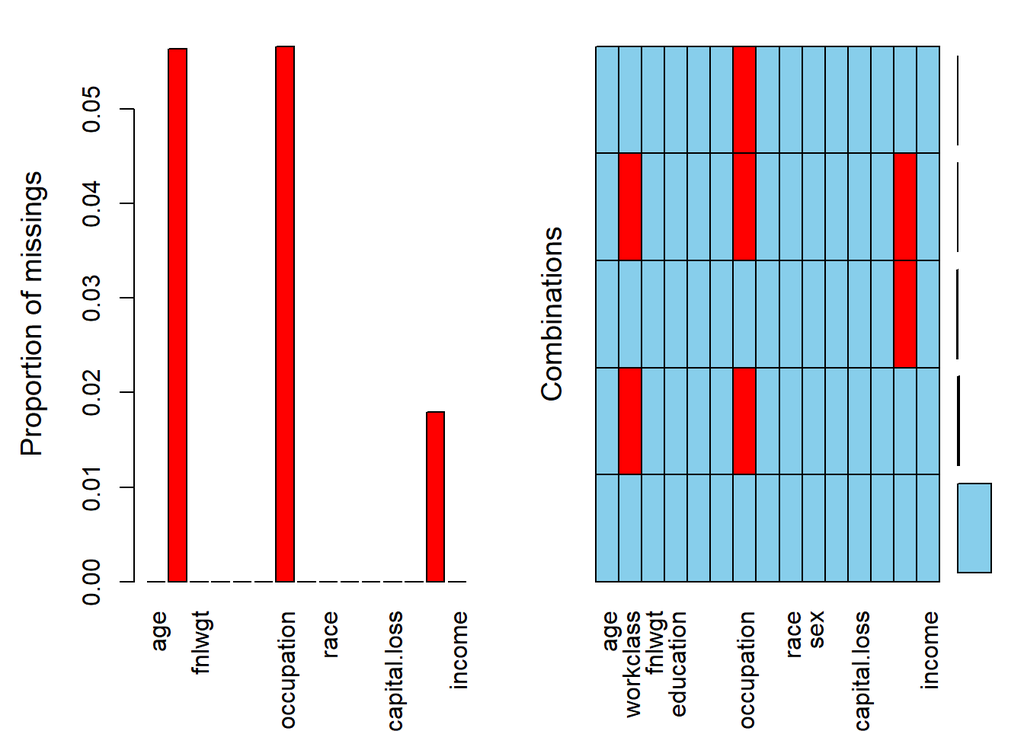

```r
library(VIM)
aggr(df)
```

6. Approach 1 to handle NAs: remove all rows that have any NAs. Save the dataset after removing as a different data. The original data is unchanged (still have NAs). How many rows left after removing?

```r
df_1 <- df %>% drop_na

nrow(df)
```

```
## [1] 32561
```

```r
nrow(df_1)
```

```
## [1] 30162
```

7. Approach 2 to handle NAs: Fill all the NAs with the previous or next value. (Hint: Using `fill` function). Save the dataset after filling as a different data. The original data is unchanged (still have NAs).

```r
df_2 <- df %>% fill(names(df),.direction = 'updown')
colSums(is.na(df_2))
```

```
##            age      workclass         fnlwgt      education  education.num
##              0              0              0              0              0
## marital.status     occupation   relationship           race            sex
##              0              0              0              0              0
##   capital.gain   capital.loss hours.per.week native.country         income
##              0              0              0              0              0
```

8. Approach 3 to handle NAs: For numeric variable, replace the NAs by the median. For categorical variables, replace the NAs to the majority.

```r
colSums(is.na(df))
```

```
##            age      workclass         fnlwgt      education  education.num
##              0           1836              0              0              0
## marital.status     occupation   relationship           race            sex
##              0           1843              0              0              0
##   capital.gain   capital.loss hours.per.week native.country         income
##              0              0              0            583              0
```

```r
str(df)
```

```
## spc_tbl_ [32,561 × 15] (S3: spec_tbl_df/tbl_df/tbl/data.frame)
##  $ age           : num [1:32561] 90 82 66 54 41 34 38 74 68 41 ...
##  $ workclass     : chr [1:32561] NA "Private" NA "Private" ...
##  $ fnlwgt        : num [1:32561] 77053 132870 186061 140359 264663 ...
##  $ education     : chr [1:32561] "HS-grad" "HS-grad" "Some-college" "7th-8th" ...
##  $ education.num : num [1:32561] 9 9 10 4 10 9 6 16 9 10 ...
##  $ marital.status: chr [1:32561] "Widowed" "Widowed" "Widowed" "Divorced" ...
##  $ occupation    : chr [1:32561] NA "Exec-managerial" NA "Machine-op-inspct" ...
##  $ relationship  : chr [1:32561] "Not-in-family" "Not-in-family" "Unmarried" "Unmarried" ...
##  $ race          : chr [1:32561] "White" "White" "Black" "White" ...
##  $ sex           : chr [1:32561] "Female" "Female" "Female" "Female" ...
##  $ capital.gain  : num [1:32561] 0 0 0 0 0 0 0 0 0 0 ...
##  $ capital.loss  : num [1:32561] 4356 4356 4356 3900 3900 ...
##  $ hours.per.week: num [1:32561] 40 18 40 40 40 45 40 20 40 60 ...
##  $ native.country: chr [1:32561] "United-States" "United-States" "United-States" "United-States" ...
##  $ income        : chr [1:32561] "<=50K" "<=50K" "<=50K" "<=50K" ...
##  - attr(*, "spec")=
##   .. cols(
##   ..   age = col_double(),
##   ..   workclass = col_character(),
##   ..   fnlwgt = col_double(),
##   ..   education = col_character(),
##   ..   education.num = col_double(),
##   ..   marital.status = col_character(),
##   ..   occupation = col_character(),
##   ..   relationship = col_character(),
##   ..   race = col_character(),
##   ..   sex = col_character(),
##   ..   capital.gain = col_double(),
##   ..   capital.loss = col_double(),
##   ..   hours.per.week = col_double(),
##   ..   native.country = col_character(),
##   ..   income = col_character()
##   .. )
##  - attr(*, "problems")=<externalptr>
```

```r
# Replacing NAs for missing variables (workclass, occupation, native.country)
df_3 <- df
majority_workclass <- names(which.max(table(df_3$workclass)))
df_3$workclass <- replace_na(df_3$workclass, majority_workclass)

majority_occupation <- names(which.max(table(df_3$occupation)))
df_3$occupation <- replace_na(df_3$occupation, majority_occupation)

majority_native.country <- names(which.max(table(df_3$native.country)))
df_3$native.country <- replace_na(df_3$native.country, majority_native.country)

colSums(is.na(df_3))
```

```
##            age      workclass         fnlwgt      education  education.num
##              0              0              0              0              0
## marital.status     occupation   relationship           race            sex
##              0              0              0              0              0
##   capital.gain   capital.loss hours.per.week native.country         income
##              0              0              0              0              0
```

```r
# There are no numeric variables with missing values, however, the following...
# ...code would be how to replace NAs with the median

##### median_variable_name <- median(df$variable_name, na.rm=TRUE)
##### df$variable_name <- replace_na(df_variable_name, median_variable_name)
```